# IPCV Part III miniproject 2

### Optimize the network design

- Change the network arquitecture, introducing more layers and neurons to obtain a better result. You can:
  - Add more and different type of layers
  - Change the activation funcions
  - Change the loss / optimizer
  - Change your initialization

Answers:

- Adding more layers increase the risk of overfitting. It was left by default since it is giving good results.
- Act. layers were left by default since best combination of them were already implemented (ReLU-sigmoid). No need to change.
- Cost function was changed to "cross-entropy". It solved the problem of gradient vanishing. The reason for that it doesn't have gradient of output in its equation.
- Uniform initialization was used instead of random. Actually, for given task they have more or less similar results. It could be left by default as well.

```
Model: "sequential_15"
_________________________________________________________________
Layer (type)                 Output Shape              Param #
=================================================================
dense_65 (Dense)             (None, 8)                 48
_________________________________________________________________
dense_66 (Dense)             (None, 16)                144
_________________________________________________________________
dense_67 (Dense)             (None, 8)                 136
_________________________________________________________________
dense_68 (Dense)             (None, 1)                 9
=================================================================
Total params: 337
Trainable params: 337
Non-trainable params: 0
_________________________________________________________________



dict_keys(['loss', 'accuracy', 'val_loss', 'val_accuracy'])
```

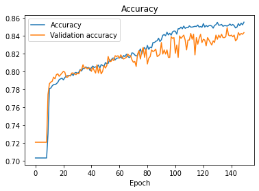

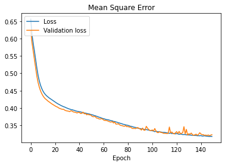

```
Model: "sequential_15"
_________________________________________________________________
Layer (type)                 Output Shape              Param #
=================================================================
dense_65 (Dense)             (None, 8)                 48
_________________________________________________________________
dense_66 (Dense)             (None, 16)                144
_________________________________________________________________
dense_67 (Dense)             (None, 8)                 136
_________________________________________________________________
dense_68 (Dense)             (None, 1)                 9
=================================================================
Total params: 337
Trainable params: 337
Non-trainable params: 0
_________________________________________________________________



Accuracy: 85.12
```

```python
# Normalize the data
from sklearn.preprocessing import MinMaxScaler
scaler = StandardScaler()
scaler.fit(x)
x = scaler.transform(x)

# Define the model using keras
model = Sequential()
model.add(Dense(8, input_dim=5, activation='relu', kernel_initializer='random_uniform'))
model.add(Dense(16, activation='relu'))
model.add(Dense(8, activation='relu')) # larger the number of neurons, larger the weight->vanishing grad
model.add(Dense(1, activation='sigmoid'))
#-------------------------------------------------------------------------------
# TO-DO block: Include your code below
#-------------------------------------------------------------------------------

model.compile(
    optimizer = 'sgd',
    loss = 'binary_crossentropy',
    metrics='accuracy'
)
#-------------------------------------------------------------------------------
# End of TO-DO block
#-------------------------------------------------------------------------------
# Network details
model.summary()
print('\n\n')
# Fit
history = model.fit(x, y, epochs=150, verbose=0, validation_split=0.2)

# Plot history

print(history.history.keys())

plt.plot(history.history['accuracy'], label='Accuracy')
plt.plot(history.history['val_accuracy'], label='Validation accuracy')
plt.title('Accuracy')
plt.ylabel('')
plt.xlabel('Epoch')
plt.legend(loc="upper left")
plt.show()

plt.plot(history.history['loss'], label='Loss')
plt.plot(history.history['val_loss'], label='Validation loss')
plt.title('Mean Square Error')
plt.ylabel('')
plt.xlabel('Epoch')
plt.legend(loc="upper left")
plt.show()

# Network details
model.summary()
print('\n\n')

# Evaluate
loss, accuracy = model.evaluate(x, y)
print('Accuracy: %.2f' % (accuracy*100))
```

# SESSION 2

### Dataset input

We are using the same dataset of SESSION 1

### Standar choice

- Evaluate the training with a standard choice of cost and activation functions, learning rate, weight initialization and network topology.
- Generate the loss and accuracy figures

### Optimizations

- Evaluate each of the following optimization methods using the same representation and the duration of the training in terms of epochs to reach a choice of error and also in terms of time taken.

  a) Regularization

  b) Dropout

  c) Stochastic gradient descent

  d) Momentum (including Nesterov version)

  e) AdaGrad

  f) RMSProp

  h) Optimize

```python
from keras.regularizers import l2
```

```python
import time
start_time = time.time()
model = Sequential()
model.add(Dense(8, input_dim=5, activation='relu'))
model.add(Dense(16, activation='relu'))
model.add(Dense(8, activation='relu'))
model.add(tf.keras.layers.Dropout(0.25)) # dropout
model.add(Dense(8, kernel_regularizer=l2(0.01), bias_regularizer=l2(0.01))) # l2 regularization
model.add(Dense(1, activation='sigmoid'))
```

```python
# Compile
model.compile(
    optimizer = 'sgd',
    loss = 'binary_crossentropy',
    metrics='accuracy'
)
```

```python
history = model.fit(x, y, epochs=150, verbose=0, validation_split=0.2)
```

```python
print("--- %s seconds ---" % (time.time() - start_time))
```

```
--- 33.958850622177124 seconds ---
```

```python
# Network details
model.summary()
print('\n\n')

# Evaluate (similar to fit but just considering 1 epoch iteration without changing the network)
loss, accuracy = model.evaluate(x,y)
print('Accuracy: %.2f' % (accuracy*100))
```

```
Model: "sequential_16"
_________________________________________________________________
Layer (type)                 Output Shape              Param #
=================================================================
dense_69 (Dense)             (None, 8)                 48
_________________________________________________________________
dense_70 (Dense)             (None, 16)                144
_________________________________________________________________
dense_71 (Dense)             (None, 8)                 136
_________________________________________________________________
dropout_4 (Dropout)          (None, 8)                 0
_________________________________________________________________
dense_72 (Dense)             (None, 8)                 72
_________________________________________________________________
dense_73 (Dense)             (None, 1)                 9
=================================================================
Total params: 409
Trainable params: 409
Non-trainable params: 0
_________________________________________________________________



Accuracy: 83.12
```

```
dict_keys(['loss', 'accuracy', 'val_loss', 'val_accuracy'])
```

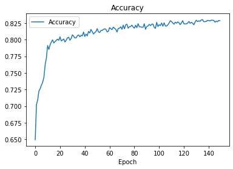

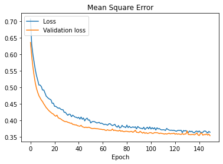

```python
# Plot history
print(history.history.keys())
plt.plot(history.history['accuracy'], label='Accuracy')
#plt.plot(history.history['val_accuracy'], label='Validation accuracy')
plt.title('Accuracy')
plt.ylabel('')
plt.xlabel('Epoch')
plt.legend(loc="upper left")
plt.show()

plt.plot(history.history['loss'], label='Loss')
plt.plot(history.history['val_loss'], label='Validation loss')
plt.title('Mean Square Error')
plt.ylabel('')
plt.xlabel('Epoch')
plt.legend(loc="upper left")
plt.show()
```

```
dict_keys(['loss', 'acc', 'val_loss', 'val_acc'])
```

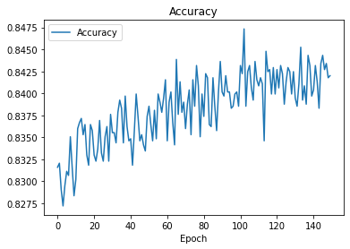

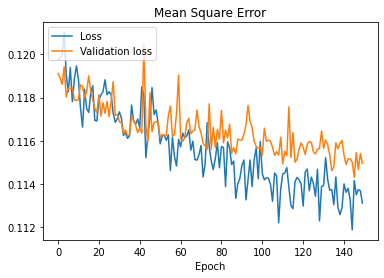

```python
# Momentum  (including Nesterov version)

# Momentum is weighted average of all gradients. Small lr is small enough to prevent bouncing around the ridge
# of pathological ravine.
optimizer = tf.keras.optimizers.SGD(learning_rate=0.01, momentum=0.5, nesterov=True, name="SGD") # stochastic gradient descent
model.compile(loss=tf.keras.losses.MeanSquaredError(),
              optimizer=optimizer,
              metrics=['acc'])
history = model.fit(x, y, epochs=150, verbose=0, validation_split=0.2)

# Plot history
print(history.history.keys())
plt.plot(history.history['acc'], label='Accuracy')
plt.title('Accuracy')
plt.ylabel('')
plt.xlabel('Epoch')
plt.legend(loc="upper left")
plt.show()
plt.plot(history.history['loss'], label='Loss')
plt.plot(history.history['val_loss'], label='Validation loss')
plt.title('Mean Square Error')
plt.ylabel('')
plt.xlabel('Epoch')
plt.legend(loc="upper left")
plt.show()
```

```
dict_keys(['loss', 'acc', 'val_loss', 'val_acc'])
```

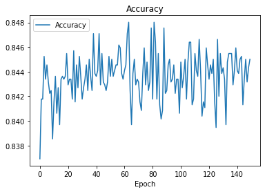

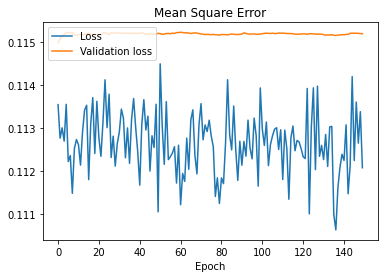

```python
#  AdaGrad
optimizer = tf.keras.optimizers.Adagrad(learning_rate=0.001)
model.compile(loss=tf.keras.losses.MeanSquaredError(),
              optimizer=optimizer,
              metrics=['acc'])
history = model.fit(x, y, epochs=150, verbose=0, validation_split=0.2)

# Plot history
print(history.history.keys())
plt.plot(history.history['acc'], label='Accuracy')
plt.title('Accuracy')
plt.ylabel('')
plt.xlabel('Epoch')
plt.legend(loc="upper left")
plt.show()
plt.plot(history.history['loss'], label='Loss')
plt.plot(history.history['val_loss'], label='Validation loss')
plt.title('Mean Square Error')
plt.ylabel('')
plt.xlabel('Epoch')
plt.legend(loc="upper left")
plt.show()
```

```
dict_keys(['loss', 'acc', 'val_loss', 'val_acc'])
```

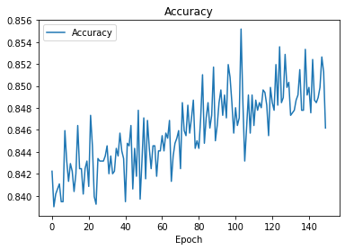

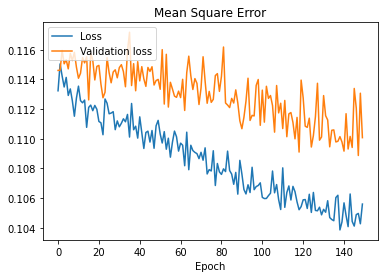

```python
# RMSProp

optimizer = tf.keras.optimizers.RMSprop(learning_rate=0.001)
model.compile(loss=tf.keras.losses.MeanSquaredError(),
              optimizer=optimizer,
              metrics=['acc'])
history = model.fit(x, y, epochs=150, verbose=0, validation_split=0.2)

# Plot history
print(history.history.keys())
plt.plot(history.history['acc'], label='Accuracy')
plt.title('Accuracy')
plt.ylabel('')
plt.xlabel('Epoch')
plt.legend(loc="upper left")
plt.show()
plt.plot(history.history['loss'], label='Loss')
plt.plot(history.history['val_loss'], label='Validation loss')
plt.title('Mean Square Error')
plt.ylabel('')
plt.xlabel('Epoch')
plt.legend(loc="upper left")
plt.show()
```

[output not shown]

### Implement parallelization in Keras with the best optimization

*It was measured the spent time for CPU, GPU, TPU of Google Colab by using following functions (in previous section):*

```python
# start_time = time.time()
# print("--- %s seconds ---" % (time.time() - start_time))
```

# **Results:**

Epochs = 150

- Execution time in Colab **GPU** (sparse_categorical_crossentropy): **220.31654453277588 sec**
- Execution time in Colab **CPU** (binary_crossentropy): **116.29094243049622 sec**
- Execution time in Colab **TPU** (SGD): **33.958850622177124 sec**

Comparisons:

- CPU is faster than GPU **1.89 times**
- TPU is faster than GPU **6,48 times**, and than CPU **3,42 times**

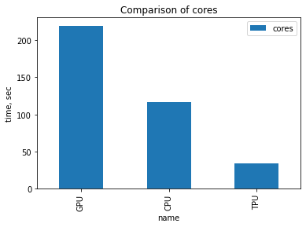

```python
import matplotlib.pyplot as plt
import pandas as pd

df = pd.DataFrame({
    'name':['GPU','CPU','TPU'],
    'cores':[220,116,34],
})


# a simple line plot
df.plot(kind='bar',x='name',y='cores')
plt.title('Comparison of cores')
plt.ylabel('time, sec')
```

### Convolutional Neural Networks

Implement a convolutional neural network and apply it to classify the images of the CIFAR-10 dataset. The network should have at least the following characteristics:

```
Convolutional layers.
Pooling layers.
Some regularization mechanism, such as dropout or L2 regularization.
Batch normalization layers.
```

The network should obtain at least 75% accuracy on the test set.

```python
# importing the dataset
(train_images, train_labels), (test_images, test_labels) = tf.keras.datasets.cifar10.load_data()
class_names = ['airplane', 'automobile', 'bird', 'cat', 'deer', 'dog', 'frog', 'horse', 'ship', 'truck']

print('train_images shape: ', train_images.shape)
print('train_labels shape: ',train_labels.shape)
for t in train_labels[:10]:
  print(t[0], class_names[t[0]])

print('test_images shape: ',test_images.shape)
print('test_labels shape: ',test_labels.shape)
for t in test_labels[:10]:
  print(t[0], class_names[t[0]])
```

```
Downloading data from https://www.cs.toronto.edu/~kriz/cifar-10-python.tar.gz
train_images shape:  (50000, 32, 32, 3)
train_labels shape:  (50000, 1)
6 frog
9 truck
9 truck
4 deer
1 automobile
1 automobile
2 bird
7 horse
8 ship
3 cat
test_images shape:  (10000, 32, 32, 3)
test_labels shape:  (10000, 1)
3 cat
8 ship
8 ship
0 airplane
6 frog
6 frog
1 automobile
6 frog
3 cat
1 automobile
```

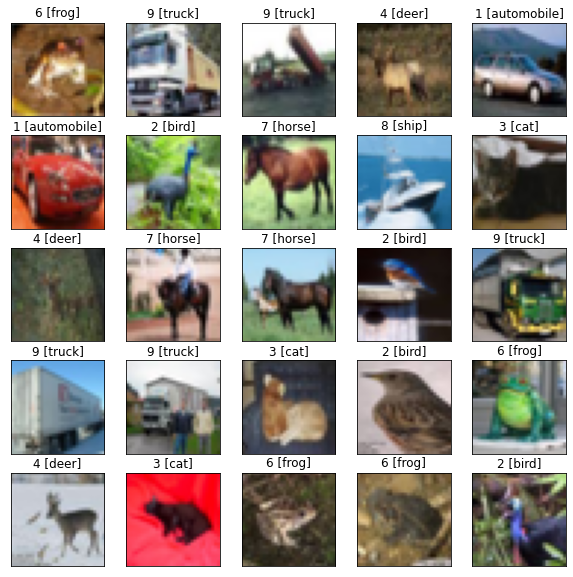

```python
# Visualization
plt.figure(figsize=(10, 10))
for i in range(25):
    plt.subplot(5, 5, i+1)
    plt.xticks([])
    plt.yticks([])
    plt.grid(False)
    plt.imshow(train_images[i])
    plt.title("%d [%s]" % (train_labels[i][0], class_names[train_labels[i][0]]))
```

https://www.tensorflow.org/tutorials/images/cnn

# *Without data augmentation*

```python
# CNN built from scratch
from keras import backend as K
from keras.utils.vis_utils import plot_model

K.clear_session()

model = tf.keras.Sequential()

model.add(tf.keras.layers.Conv2D(32, (3, 3), activation='relu', input_shape=(32, 32, 3)))
model.add(tf.keras.layers.BatchNormalization())
model.add(tf.keras.layers.MaxPooling2D((2, 2)))

model.add(tf.keras.layers.Conv2D(64, (3, 3), activation='relu'))
model.add(tf.keras.layers.BatchNormalization())
model.add(tf.keras.layers.MaxPooling2D((2, 2)))

model.add(tf.keras.layers.Conv2D(64, (3, 3), activation='relu'))
model.add(tf.keras.layers.BatchNormalization())

model.add(tf.keras.layers.Flatten())
model.add(tf.keras.layers.Dense(64, activation='relu'))
model.add(tf.keras.layers.Dense(10, activation = 'softmax'))
```

```python
model.compile(optimizer='adam',
              loss=tf.keras.losses.SparseCategoricalCrossentropy(from_logits=True),
              metrics=['accuracy'])

history = model.fit(train_images, train_labels, epochs=10,
                    validation_data=(test_images, test_labels))
```

```
313/313 - 5s - loss: 1.1092 - accuracy: 0.6947
```

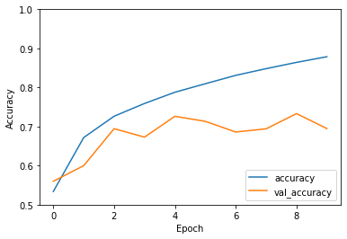

```python
plt.plot(history.history['accuracy'], label='accuracy')
plt.plot(history.history['val_accuracy'], label = 'val_accuracy')
plt.xlabel('Epoch')
plt.ylabel('Accuracy')
plt.ylim([0.5, 1])
plt.legend(loc='lower right')

test_loss, test_acc = model.evaluate(test_images,  test_labels, verbose=2)
```

# *With data augmentation*

```python
train_images_orig = train_images
test_images_orig = test_images
mean_img = train_images.mean(axis=0)
train_images = train_images - mean_img
test_images = test_images - mean_img
```

```python
from keras.preprocessing.image import ImageDataGenerator
datagen = ImageDataGenerator(width_shift_range=0.1,
                             height_shift_range=0.1,
                             rotation_range=15,
                             horizontal_flip=True)

iter = datagen.flow(train_images_orig[:10], train_labels[:10], batch_size=10)
```

```python
# CNN built from scratch
from keras import backend as K
from keras.utils.vis_utils import plot_model

K.clear_session()

model = tf.keras.Sequential()

model.add(tf.keras.layers.Input(shape=(32, 32, 3)))

model.add(tf.keras.layers.Conv2D(32, kernel_size=3, activation='relu', padding='same'))
model.add(tf.keras.layers.BatchNormalization())
model.add(tf.keras.layers.Conv2D(32, kernel_size=3, activation='relu', padding='same'))
model.add(tf.keras.layers.BatchNormalization())
model.add(tf.keras.layers.MaxPool2D(pool_size=2))

model.add(tf.keras.layers.Conv2D(64, kernel_size=3, activation='relu', padding='same'))
model.add(tf.keras.layers.BatchNormalization())
model.add(tf.keras.layers.Conv2D(64, kernel_size=3, activation='relu', padding='same'))
model.add(tf.keras.layers.BatchNormalization())
model.add(tf.keras.layers.MaxPool2D(pool_size=2))

model.add(tf.keras.layers.Conv2D(128, kernel_size=3, activation='relu', padding='same'))
model.add(tf.keras.layers.BatchNormalization())
model.add(tf.keras.layers.Conv2D(128, kernel_size=3, activation='relu', padding='same'))
model.add(tf.keras.layers.BatchNormalization())
model.add(tf.keras.layers.MaxPool2D(pool_size=2))

model.add(tf.keras.layers.Flatten())
model.add(tf.keras.layers.Dense(512, activation='relu'))
model.add(tf.keras.layers.BatchNormalization())
model.add(tf.keras.layers.Dropout(0.5))
model.add(tf.keras.layers.Dense(10, activation='softmax'))
```

```python
train_labels_one_hot = keras.utils.to_categorical(train_labels, 10)
test_labels_one_hot = keras.utils.to_categorical(test_labels, 10)
```

```python
model.compile(optimizer=keras.optimizers.Adam(learning_rate=1.e-3), loss='categorical_crossentropy', metrics=['acc'])
iter = datagen.flow(train_images, train_labels_one_hot, batch_size=1000)
```

```python
nepochs = 10
history = model.fit(iter,
                    epochs=nepochs,
                    steps_per_epoch=50,
                    validation_data=(test_images, test_labels_one_hot))
```

```
313/313 - 19s - loss: 0.6255 - acc: 0.7942
```

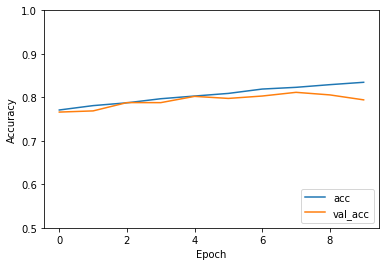

```python
plt.plot(history.history['acc'], label='acc')
plt.plot(history.history['val_acc'], label = 'val_acc')
plt.xlabel('Epoch')
plt.ylabel('Accuracy')
plt.ylim([0.5, 1])
plt.legend(loc='lower right')

test_loss, test_acc = model.evaluate(test_images,  test_labels_one_hot, verbose=2)
```

# **Conclusion:**

However, need to note that data augmentation is major boost of the accuracy. As we know, CNN is not invariant to rotations, that's why we implemented simple rotations of the image to enlarge the training set. Correspondingly, model got more data to learn, and accuracy was increased. Finally, model got accuracy of **79%**.

```python
!jupyter nbconvert --to html /content/MiniprojectpartIII_Baglan_AITU.ipynb
```

```
[NbConvertApp] Converting notebook /content/MiniprojectpartIII_Baglan_AITU.ipynb to html
[NbConvertApp] Writing 1309324 bytes to /content/MiniprojectpartIII_Baglan_AITU.html
```